# Módulo 5

### Ejemplo divergente

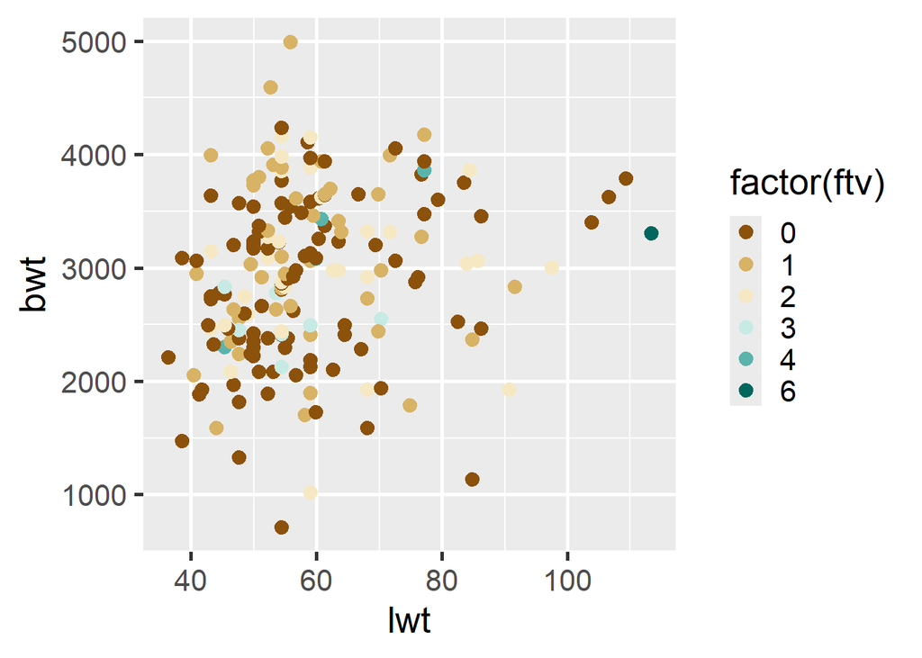

```r
ggplot(bwt, aes(lwt,bwt, color=factor(ftv))) +
  geom_point()+scale_colour_brewer(palette = "BrBG")
```

### Paletas continuas

En el caso de trabajar con datos continuos hay que usar la instrucción `scale_colour_fermenter`

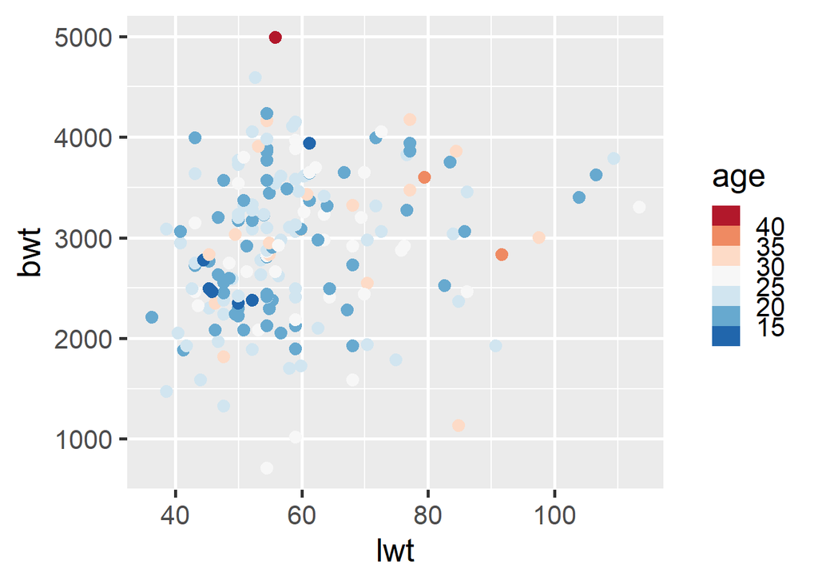

```r
ggplot(bwt, aes(lwt,bwt, color=age)) + geom_point()+
  scale_colour_fermenter(palette = "RdBu")
```

### Viridis

Del paquete Viridis: A (magma), B (inferno), C (plasma), D (viridis), E (cividis), F (rocket), G (mako).

El paquete viridis organiza las paletas entre discretas y continuas en función de si se usa la instrucción `scale_colour_viridis_d` o `scale_colour_viridis_c` respectivamente.

### Ejemplo categórico/discreto

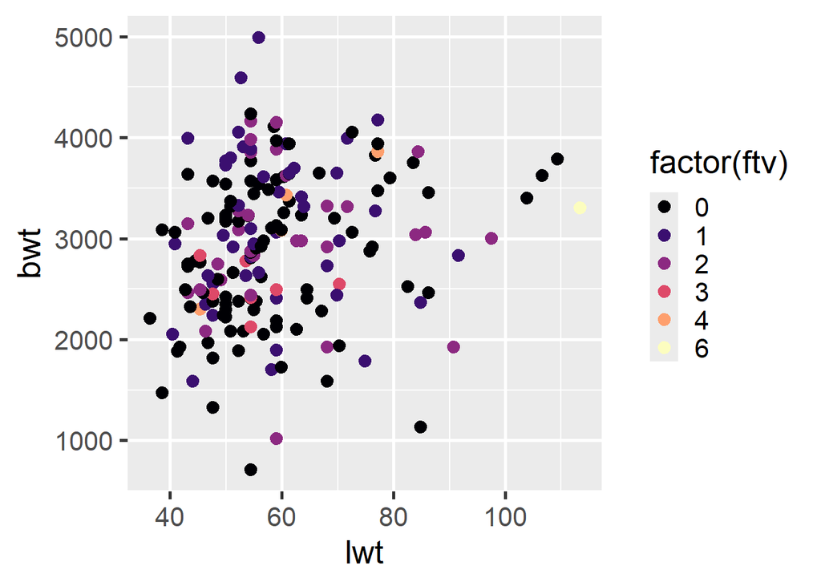

```r
ggplot(bwt, aes(lwt,bwt, color=factor(ftv))) +
  geom_point()+
  scale_colour_viridis_d(option = "A")
```

### Ejemplo continuo

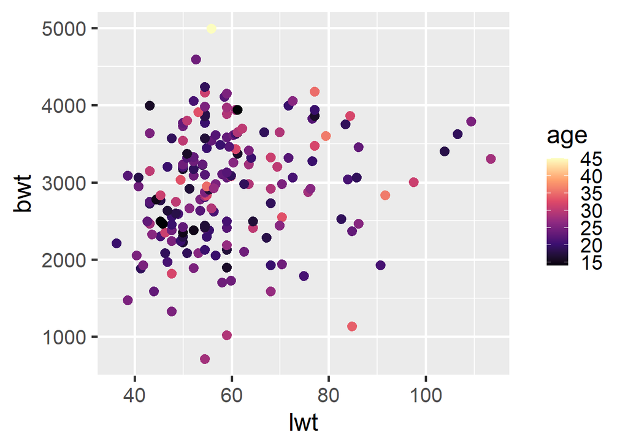

```r
ggplot(bwt, aes(lwt,bwt, color=age)) + geom_point()+
  scale_colour_viridis_c(option = "A")
```

### A mano

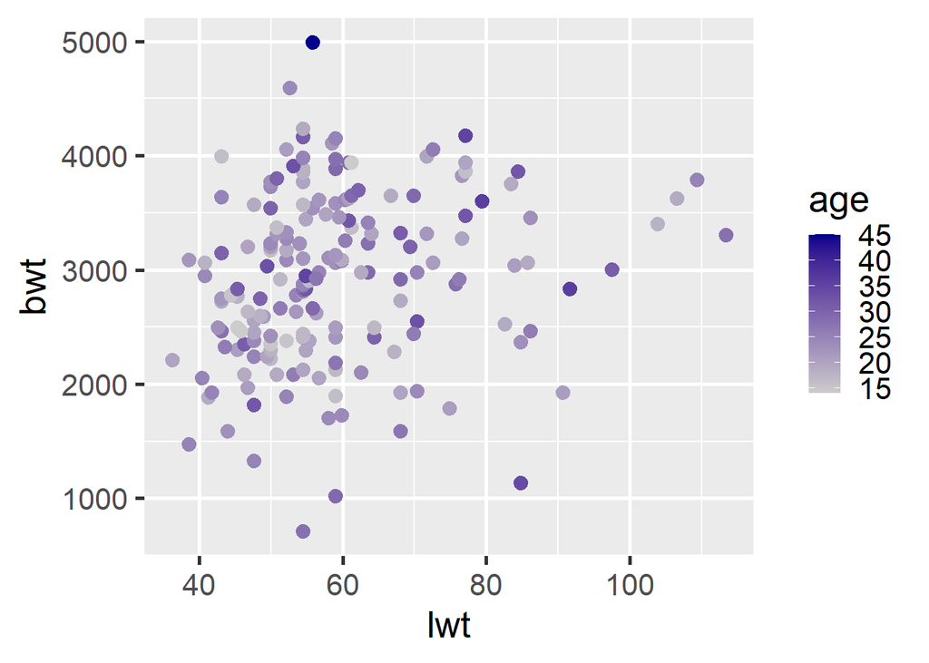

```r
ggplot(bwt, aes(lwt,bwt, color=age)) + geom_point()+
  scale_color_gradient(low = "grey80", high = "darkblue")
```

### A mano

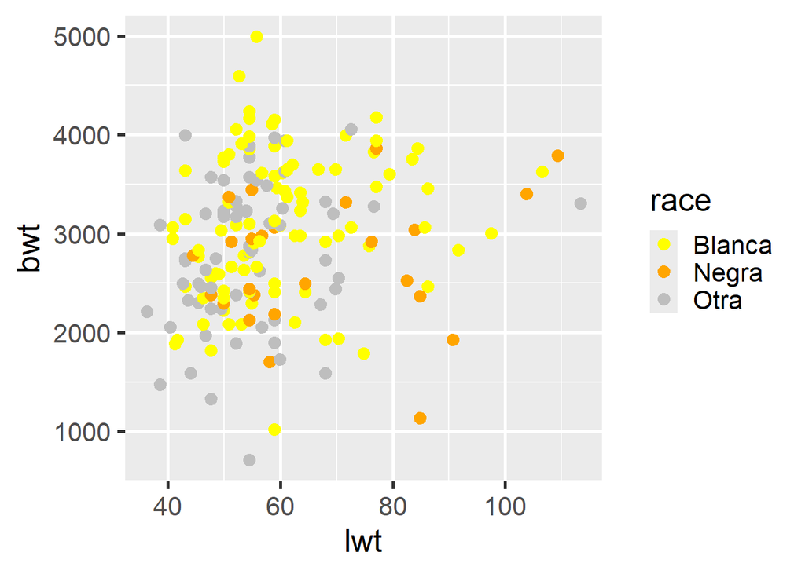

```r
ggplot(bwt, aes(lwt,bwt, color=race)) + geom_point()+
  scale_color_manual(values= c(Negra = "orange",
  Blanca = "yellow", Otra = "gray"))
```

### Color fijo

**OJO:** si queremos colorear en función de un dato, lo indicaremos dentro de aes, en cambio si queremos colorear todo igual lo haremos fuera de aes. Esto será asi para cualquier parámetro que usemos.

### Ejemplo uso incorrecto color fijo

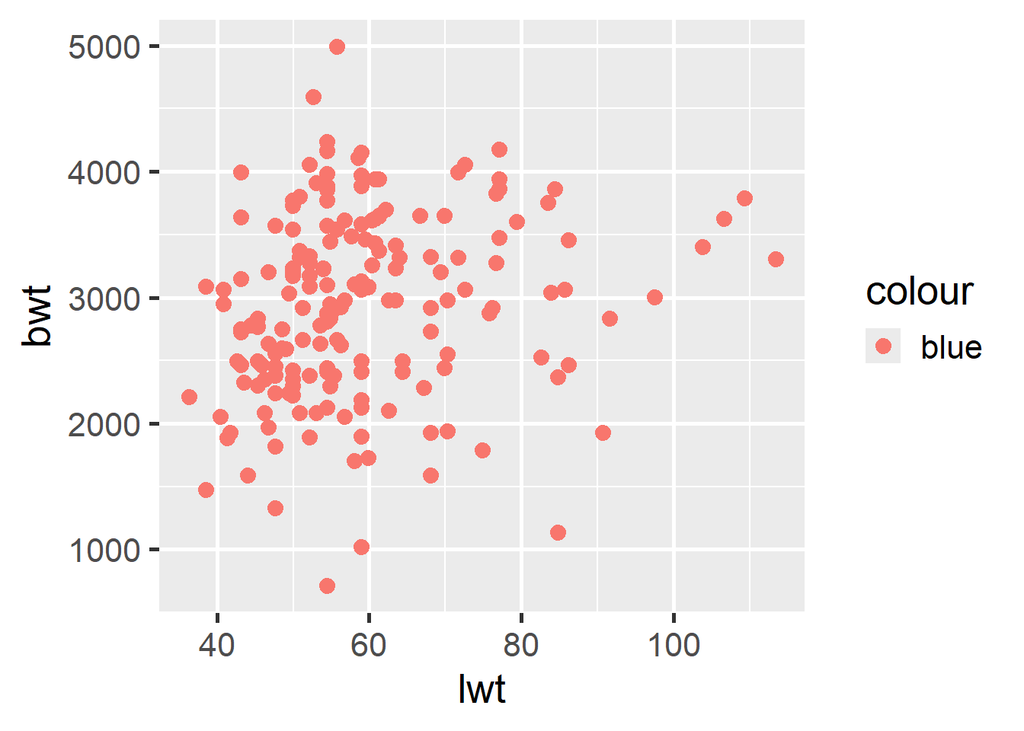

```r
ggplot(bwt, aes(lwt,bwt)) +
  geom_point(aes(color = "blue"))
```

### Ejemplo uso correcto color fijo

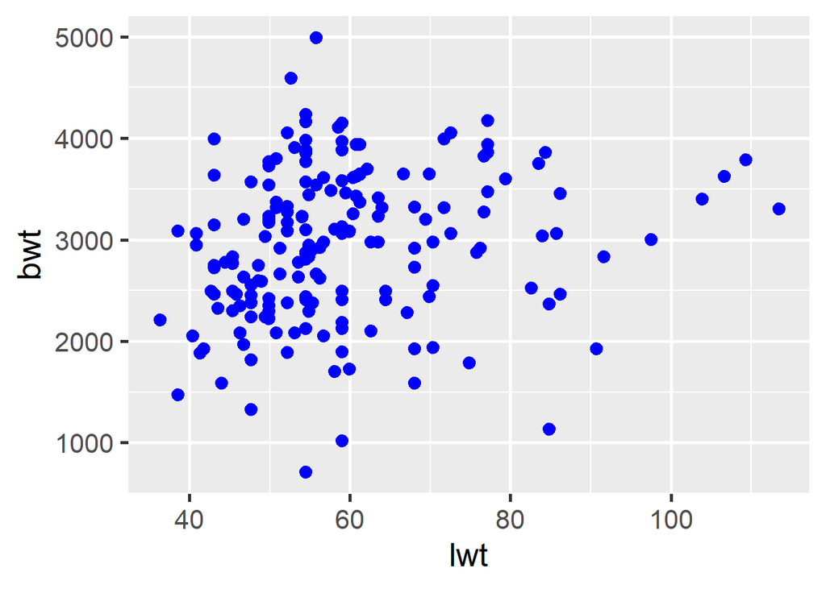

```r
ggplot(bwt, aes(lwt,bwt)) + geom_point(color = "blue")
```

### Tamaños

También podemos ajustar el tamaño de los puntos en función de una variable o de forma global.

### Ejemplo tamaño dependiente

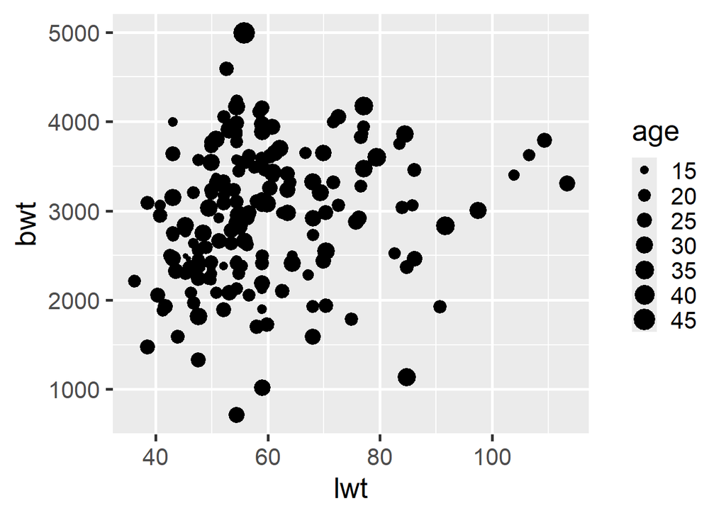

```r
ggplot(bwt, aes(lwt,bwt))+geom_point(aes(size = age))
```

### Ejemplo tamaño fijo

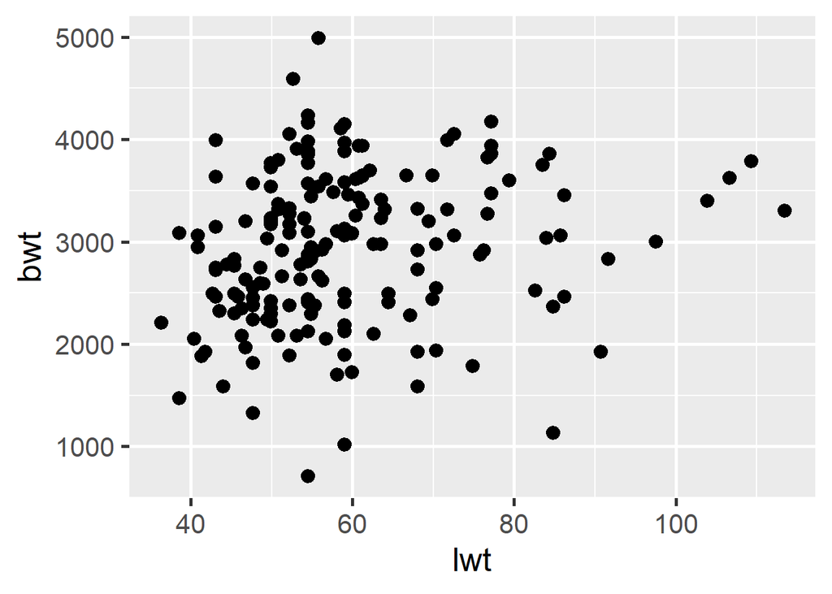

```r
ggplot(bwt, aes(lwt,bwt)) + geom_point(size = 3)
```

### Formas

De la misma manera podemos asignar formas en función de una categoría o fijar una forma a todo el dibujo

### Forma dependiente

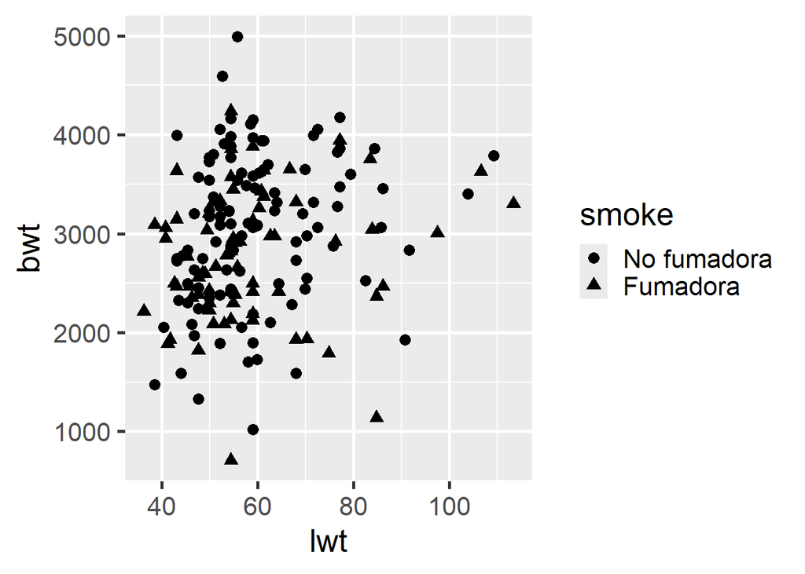

```r
ggplot(bwt, aes(lwt,bwt)) +
  geom_point(aes(shape = smoke))
```

### Forma fija

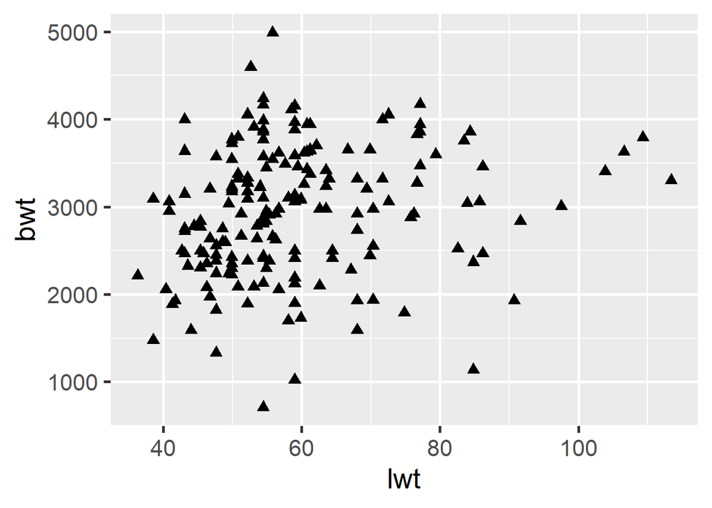

```r
ggplot(bwt, aes(lwt,bwt)) + geom_point(shape = 17)
```

### `ggpubr`

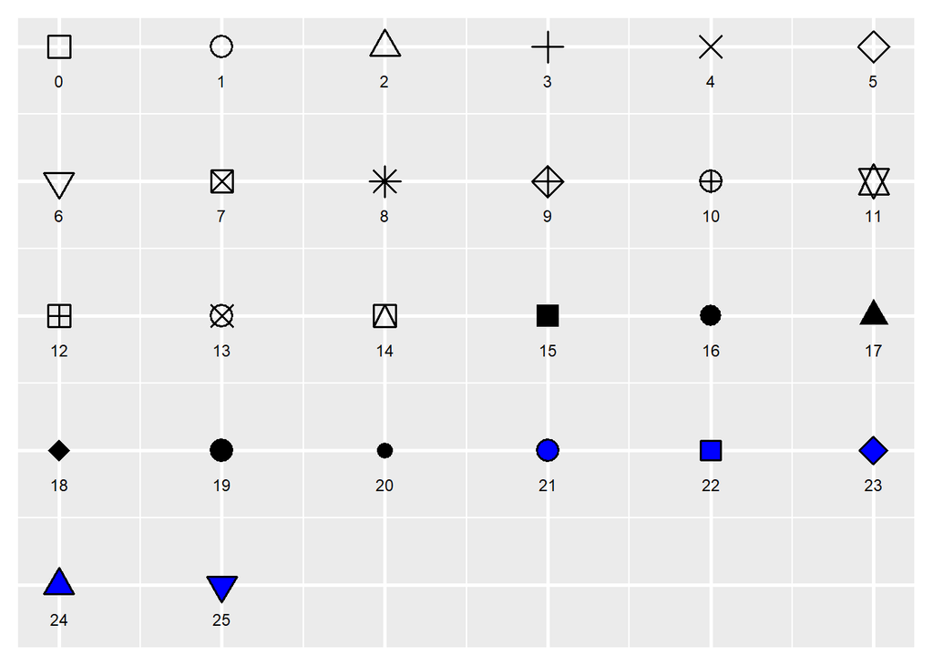

En el caso de usar más de 25 formas, `ggplot2` usa carácteres ascii. Llegados a ese punto mejor dividir el dibujo en varios.

### Bordes y `fill`

Podemos editar el borde de manera diferente al relleno usando `fill`, exclusivo de las figuras 21 hasta 25.

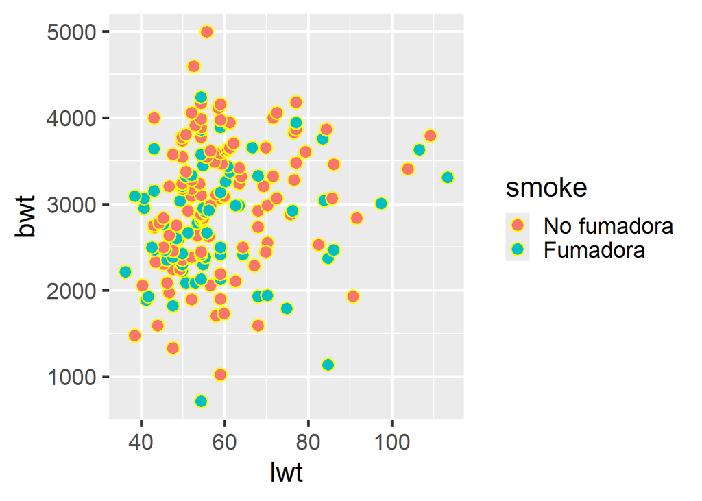

```r
ggplot(bwt, aes(lwt,bwt)) +
  geom_point(aes(fill = smoke),color = "yellow",
             shape = 21,size = 4)
```

### Bordes y `stroke`

También podemos alterar el grosor del borde usando `stroke`

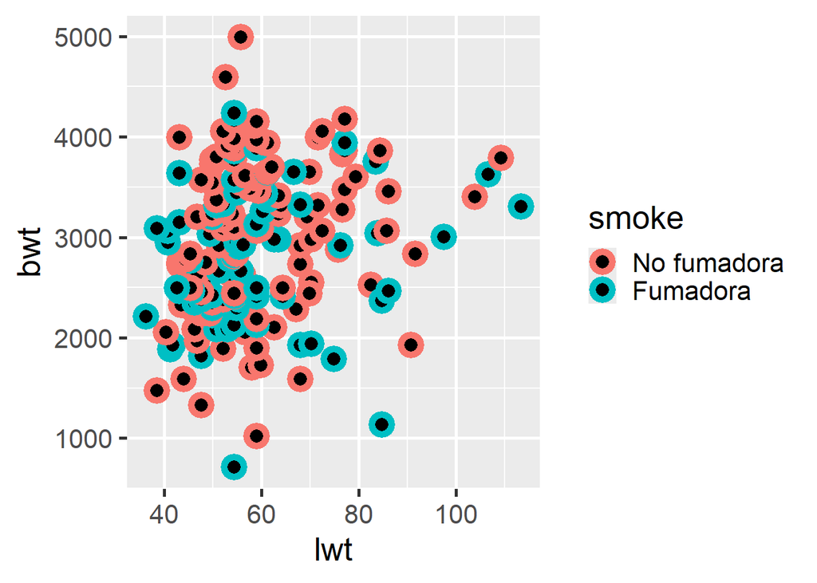

```r
ggplot(bwt, aes(lwt,bwt)) +
  geom_point(aes(color = smoke),fill = "black",
             shape = 21,size = 4,stroke = 3)
```

### Alpha

Cuando hay muchas figuras reducir la opacidad mejora la visualización.

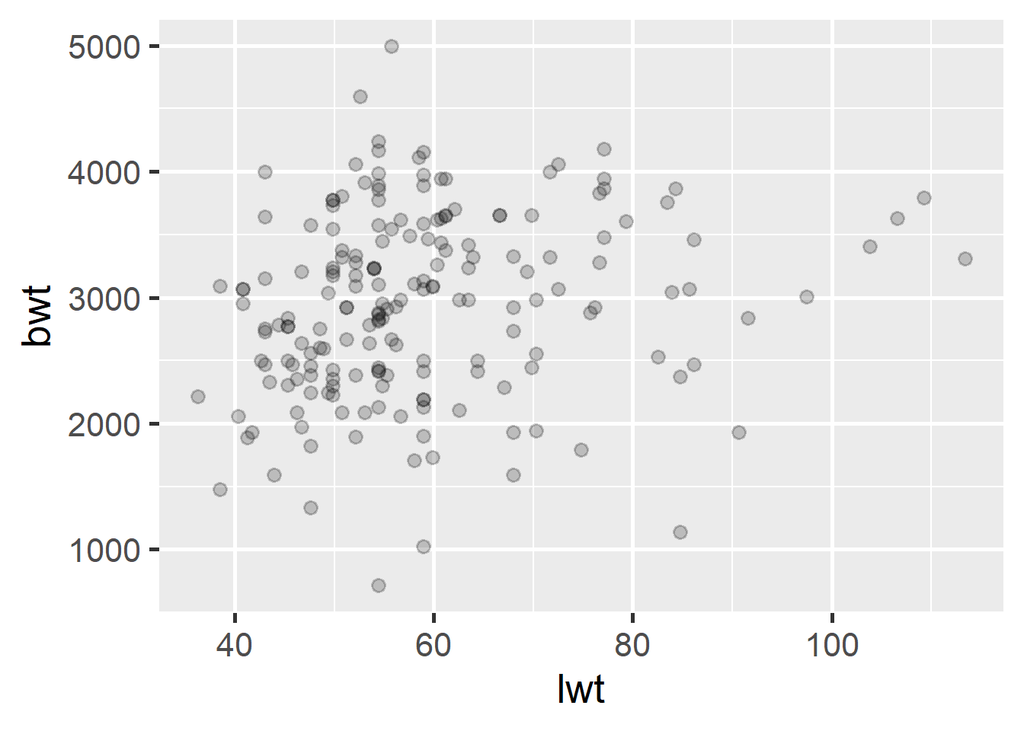

```r
ggplot(bwt, aes(lwt,bwt)) +
  geom_point(alpha = 0.2, size = 2.5)
```

### Facetting

Para hacer un dibujo por categoría, basta añadir la instrucción `facet_wrap` si queremos superponerlos, hacemos group.

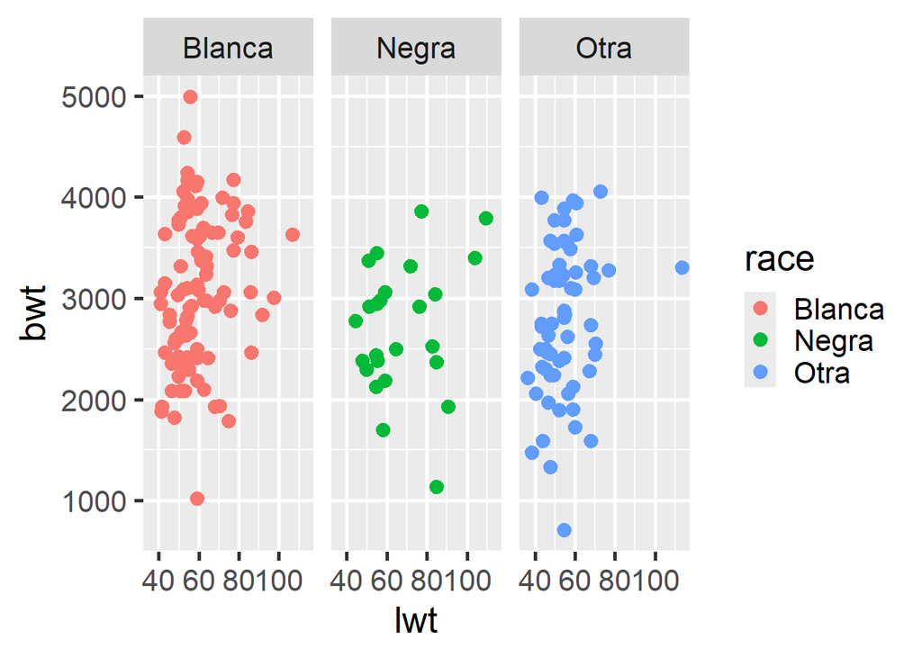

```r
ggplot(bwt, aes(lwt,bwt)) +
  geom_point(aes(color = race))+ facet_wrap(~race)
```

**OJO:** hay que añadir el ~ antes del nombre de la categoría.

### Leyenda y ejes

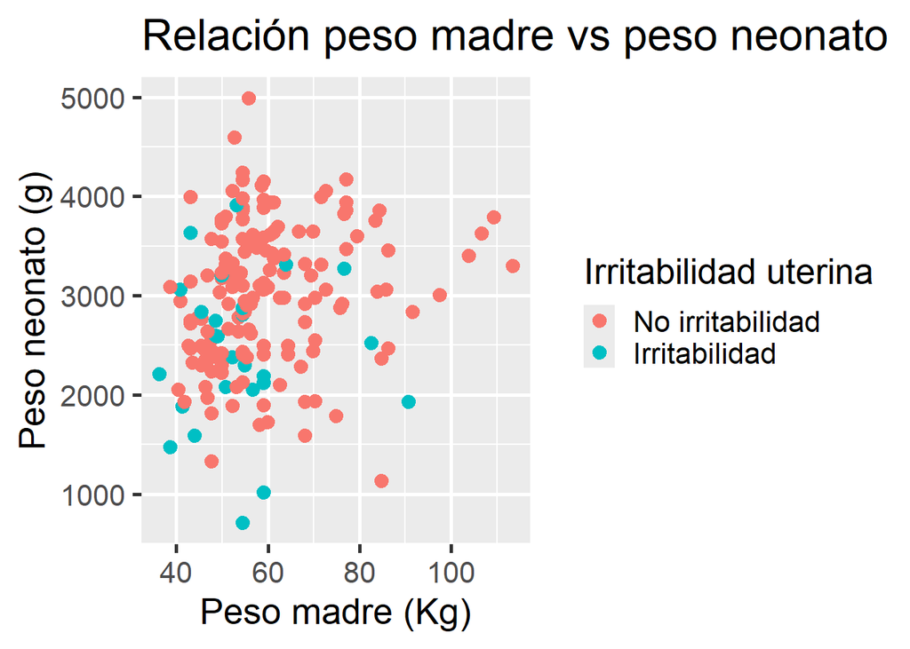

```r
ggplot(bwt, aes(lwt,bwt)) + geom_point(aes(color=ui))+
  labs(y= "Peso neonato (g)",
       x="Peso madre (Kg)",
       title = "Relación peso madre vs peso neonato",
       color = "Irritabilidad uterina")
```

Para ajustar el nombre de la leyenda ponemos el nombre del parámetro que se está usando para que aparezca.

### Quitar leyenda

También podemos eliminar la leyenda completamente.

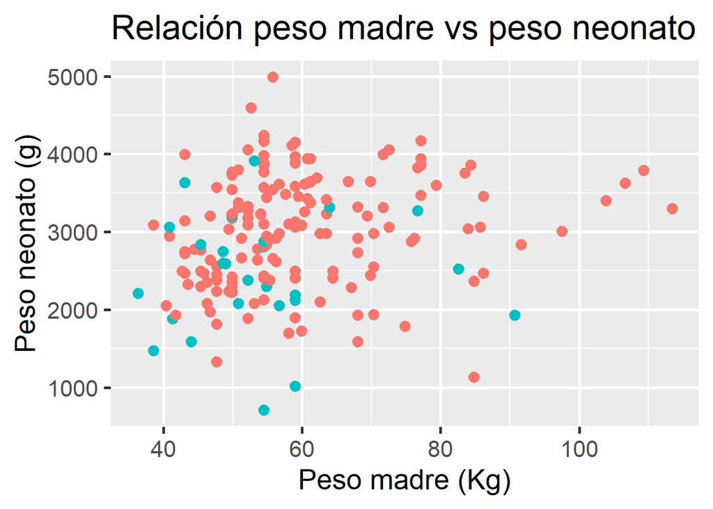

```r
ggplot(bwt, aes(lwt,bwt)) +
  geom_point(aes(color=ui),show.legend = FALSE)+
  labs(y= "Peso neonato (g)",
       x="Peso madre (Kg)",
       title = "Relación peso madre vs peso neonato")
```

### Escalas

Es posible manipular manualmente el tamaño de los ejes.

```
Warning: Removed 4 rows containing missing values or values outside the scale range
(`geom_point()`).
```

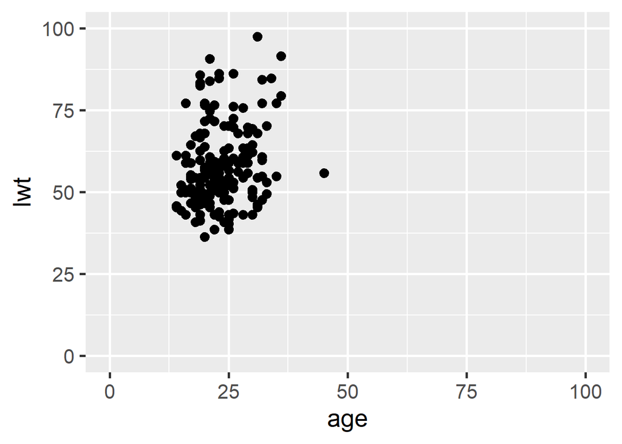

```r
ggplot(bwt,aes(age,lwt))+
  geom_point()+
  xlim(0,100)+
  ylim(0,100)
```

En este caso R nos da el aviso de hay puntos que no están encuadrados.

### Elegir solo uno de los extremos

Podemos usar `NA` para que R decidá por nosotros el valor.

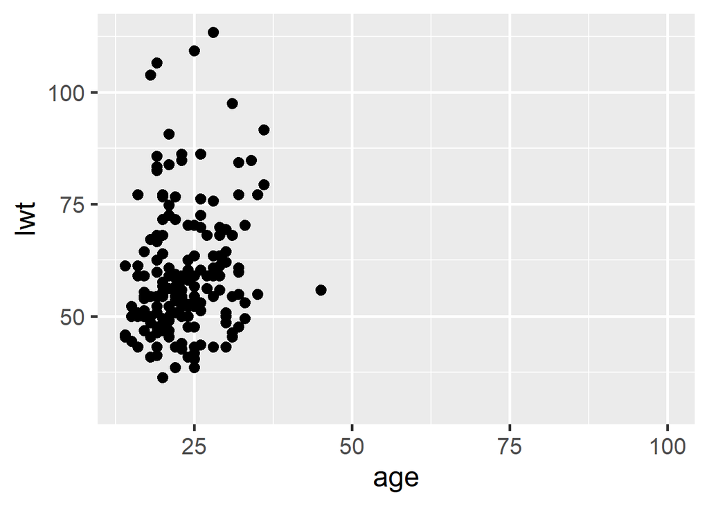

```r
ggplot(bwt,aes(age,lwt))+
  geom_point()+
  xlim(NA,100)+
  ylim(30,NA)
```

### Temas

Podemos elegir entre varios temas.

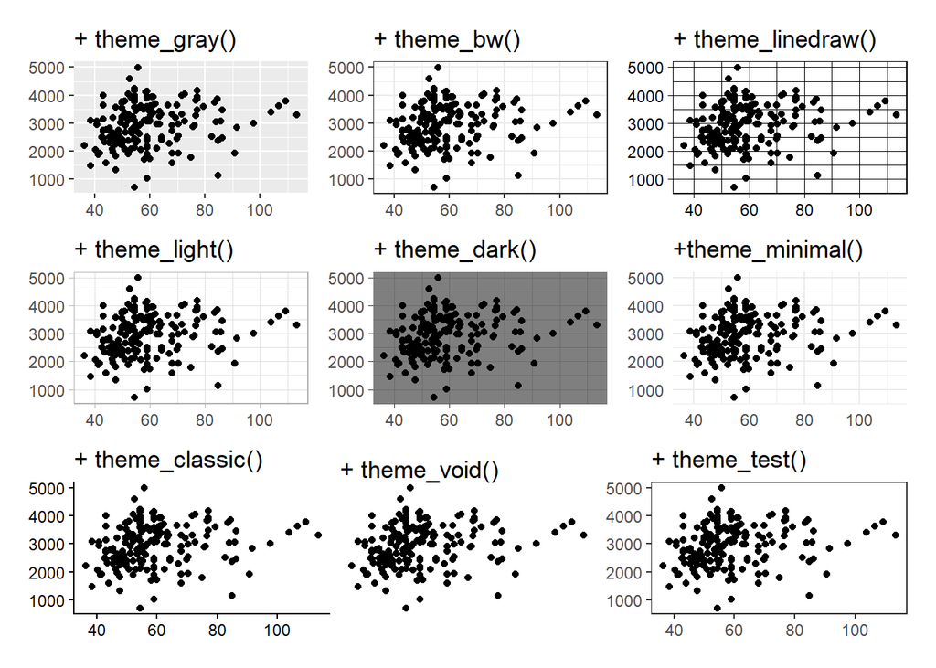

### Creación de un tema personalizado

```r
##| cache-rebuild: true
theme_everything <- theme(
  line = element_line(colour = "gray20",
                      linewidth = 0.5, linetype = 1,
                      lineend = "butt"),
  rect = element_rect(fill = "white", colour = NA,
                      linewidth = 0.5, linetype = 1),
  text = element_text(family = "comicsans",face = "plain",
                      colour = "gray10", size = 32,
                      lineheight = 0.9, hjust = 0,
                      vjust = 0, margin = margin(),
                      angle = 0),
  axis.title = element_text(face = "bold", size = 20),
  axis.title.x = element_text(margin = margin(t = 8)),
  axis.title.y = element_text(margin = margin(r = 8),
                              angle = 45),
  axis.text = element_text(colour = "red"))
```